# Projects Highlights

# Project 1

**Ref.:** Wu KM, Riley S. Estimation of the basic reproductive number and mean serial interval of a novel pathogen in a small, well-observed discrete population. *PLoS One* 2016, 11(2): e0148061. [[link]](https://doi.org/10.1371/journal.pone.0148061)[[source code]](https://github.com/kendrawu/EpiInference)

## Why Was This Study Done?

Accurately assessing the ability for a novel human pathogen to spread from one person to another (i.e., transmissibility) and the average time between these transmissions of each infector-infectee pair is a public health priority because the timing and required strength of interventions may therefore be determined. Recent theoretical work has focused on making the best use of data from the initial phase of an epidemic incidence in large populations[[1]](https://onlinelibrary.wiley.com/doi/abs/10.1002/sim.3136)[[2]](https://onlinelibrary.wiley.com/doi/abs/10.1111/j.1750-2659.2009.00106.x)[[3]](https://academic.oup.com/biostatistics/article/12/2/303/280518)[[4]](https://academic.oup.com/aje/article/160/6/509/79472). This study attempted to extend the work to assess the data of all phases of an epidemic in populations of all sizes, including small populations.

## Methods

We measured how quickly a disease spread from one case to another by a parameter called the basic reproductive number $R_0$ (which is formally defined as the average number of infected cases per each typical infector in a susceptible population) and the serial interval (which is defined as the average time between successive cases) by its mean $T_g$. First, we constructed a simulation algorithm for case data arising from a small population of known size with $R_0$ and $T_g$ also known. We then developed an inferential model for the likelihood of these case data as a function of $R_0$ and $T_g$. The model was designed to capture a) any signal of the serial interval distribution in the initial stochastic phase, b) the growth rate of the exponential phase, and c) the unique combination of $R_0$ and $T_g$ that generates a specific shape of peak incidence when the susceptible portion of a small population is depleted.

## Results

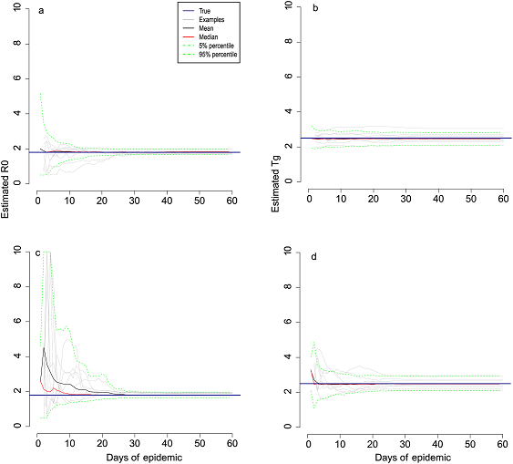

**Figure 1**: Part **a** shows real-time univariate estimates of $R_0$ in which the true value of $T_g$ was assumed known. Part **b** shows real-time univariate estimates of $T_g$ with $R_0$ assumed known. The results of jointly estimating $R_0$ and $T_g$ are shown in parts **c** ($R_0$) and **d** ($T_g$). This scenario is with $R_0$ = 1.8, $T_g$ = 2.5. The epidemic was simulated in a population of 1,000 people all of whom were initially susceptible, other than 50 who were infectious on day 1. Grey lines trace the corresponding estimates of 8 arbitrary epidemics. Black lines represent the average of 100 estimates at that time point, red lines represent the median, and the green dotted lines are the 5% and 95% prediction intervals for 100 epidemics. The dark blue solid horizontal lines show the true parameter values.

## What Do These Findings Mean?

Repeated application of these methods to small scale outbreaks at the start of an epidemic would permit accurate estimates of key parameters.

## Funding

I am very grateful to receive funding from the following sources: John Swire & Sons Ltd, The University of Hong Kong, HKU Li Ka Shing Faculty of Medicine, Cathay Pacific Airways.

Copyright © 2018 Kendra M Wu. All rights reserved. Last Update: 18 Sept 2018